V The V Lab

# R Markdown: A Practical Guide to knitr and kable()

A Reproducible Guide to Dynamic Reports, knitr, and kable()

The V Lab Learning Module

Updated August 11, 2026

**Audience**R Markdown beginners

**Study time**60–90 minutes

**Prerequisites**Basic R is helpful

# 1 Learning goals

This tutorial shows how to create a reproducible report that combines narrative, R code, computed results, plots, and tables. By the end, you should be able to:

- structure an `.Rmd` file with YAML, Markdown, and executable code;
- control code and output with **knitr chunk options**;
- render the source to a self-contained HTML document;
- create clear tables with `knitr::kable()`; and
- avoid common reproducibility, caching, and table-formatting problems.

**Terminology:** `knitr` is an R package. `kable()` is a function exported by `knitr`, not a separate package. The optional `kableExtra` package adds advanced styling, but it is not required for the examples in this guide.

# 2 What R Markdown does

An R Markdown document is a plain-text source file. It keeps the explanation and the analysis together, which makes the report easier to reproduce and update.

**Rendering pipeline**  
`.Rmd source` → `knitr` executes code and creates Markdown/assets → `Pandoc` converts them →

```
HTML, Word, PDF, or another
output
```

Two functions in this pipeline have different jobs:

- `knitr::knit()` executes chunks and normally creates an intermediate Markdown document.
- `rmarkdown::render()` coordinates `knitr`, Pandoc, and the requested output format to create the final document.

R Markdown is useful for exploratory analyses, course assignments, laboratory reports, dashboards, model summaries, automated recurring reports, and technical documentation.

# 3 Install once, render many times

Install the required packages from the R console. Do not put package installation in an automatically executed report: rendering should not unexpectedly modify a reader’s R library.

```r
install.packages(c("rmarkdown", "knitr"))
```

Render from RStudio’s **Knit** button or from the R console:

```r
rmarkdown::render(
  "r_markdown_guide_en.Rmd",
  output_file = "r_markdown_guide_en.html",
  encoding = "UTF-8"
)
```

Pandoc is also required. RStudio includes it; otherwise install Pandoc separately and make it available to `rmarkdown`.

# 4 Anatomy of an `.Rmd` file

An R Markdown file normally has three parts.

## 4.1 1. YAML front matter

The YAML block at the top stores metadata and output settings. Indentation uses spaces, not tabs.

```markdown
---
title: "Analysis title"
author: "Analyst name"
date: "2026-08-11"
params:
  min_mpg: 20
output:
  html_document:
    toc: true
    number_sections: true
    code_folding: show
    self_contained: true
---
```

Useful HTML options include a table of contents (`toc`), numbered sections, syntax highlighting, floating navigation, and collapsible source code. A self-contained HTML file embeds local CSS, JavaScript, and generated figures so the result is easy to share as one file.

## 4.2 2. Markdown prose

Markdown supplies lightweight formatting:

```markdown
# Level-one heading
## Level-two heading

**bold text**, *italic text*, and `inline code`

- an unordered item
- another item

1. a numbered item
2. another item

[R Markdown documentation](https://pkgs.rstudio.com/rmarkdown/)

> A block quotation

Inline mathematics: $\bar{x} = \frac{1}{n}\sum_{i=1}^{n}x_i$

Displayed mathematics:
$$
s^2 = \frac{1}{n-1}\sum_{i=1}^{n}(x_i-\bar{x})^2
$$
```

Blank lines matter: they separate paragraphs, lists, and block-level output.

## 4.3 3. R code chunks and inline R

A chunk starts with three backticks and `{r}`, and ends with three backticks. Give every executed chunk a unique, meaningful label.

````markdown
``` r
summary(mtcars$mpg)
```

```
##    Min. 1st Qu.  Median    Mean 3rd Qu.    Max.
##   10.40   15.43   19.20   20.09   22.80   33.90
```
````

Inline R inserts a short result directly into a sentence. For example, `mtcars` has 32 rows, and its mean fuel economy is 20.1 miles per gallon. Inline expressions should be short and should depend on objects created earlier in the document.

# 5 A small reproducible analysis

All required objects are created inside this document, so the report does not depend on an interactive Global Environment.

```r
cars_data <- data.frame(
  Model = rownames(mtcars),
  mtcars[, c("mpg", "cyl", "hp", "wt")],
  row.names = NULL,
  check.names = FALSE
)

names(cars_data) <- c("Model", "MPG", "Cylinders", "Horsepower", "Weight")
head(cars_data)
```

| Model | MPG | Cylinders | Horsepower | Weight |
| --- | --- | --- | --- | --- |
| Mazda RX4 | 21.0 | 6 | 110 | 2.620 |
| Mazda RX4 Wag | 21.0 | 6 | 110 | 2.875 |
| Datsun 710 | 22.8 | 4 | 93 | 2.320 |
| Hornet 4 Drive | 21.4 | 6 | 110 | 3.215 |
| Hornet Sportabout | 18.7 | 8 | 175 | 3.440 |
| Valiant | 18.1 | 6 | 105 | 3.460 |

The following plot is generated when the document is knitted. `fig.cap` adds a caption; `fig.width` controls the graphics device size in inches, whereas `out.width` controls its displayed size in the HTML page.

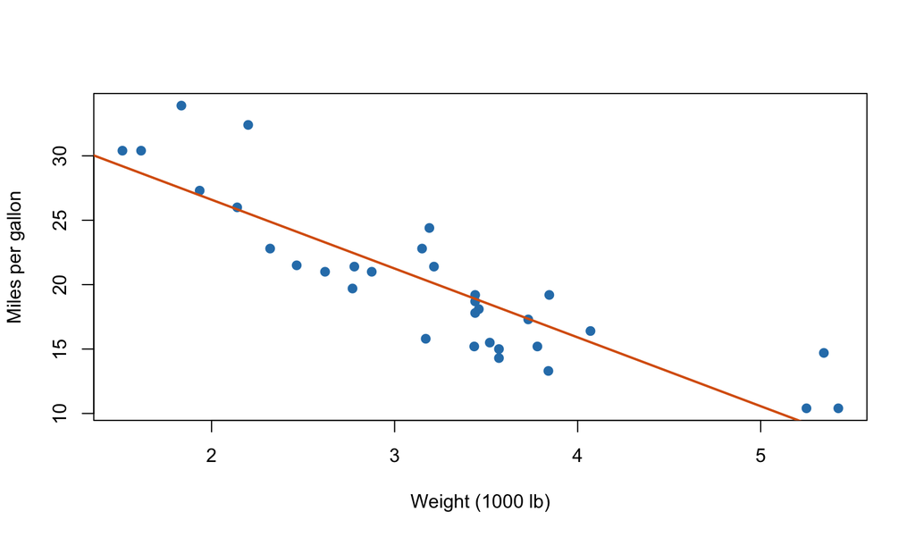

Fuel economy generally decreases as vehicle weight increases.

```r
plot(
  mtcars$wt,
  mtcars$mpg,
  xlab = "Weight (1000 lb)",
  ylab = "Miles per gallon",
  pch = 19,
  col = "#2c7fb8"
)

weight_fit <- lm(mpg ~ wt, data = mtcars)
abline(weight_fit, col = "#d95f0e", lwd = 2)
```

# 6 `knitr` in depth

`knitr` implements the literate-programming layer of R Markdown: it finds code chunks, evaluates them in order, captures text/graphics/messages, and writes the results into the intermediate document.

## 6.1 Global and local chunk options

The hidden `setup` chunk at the beginning of this file uses `knitr::opts_chunk$set()` to define defaults. A local option in a chunk header overrides the global value only for that chunk.

```
## This result is visible even though this chunk's source is hidden.
```

The source above was executed because `eval` remained `TRUE`; only its display was changed by `echo=FALSE`.

## 6.2 Essential chunk options

Frequently used knitr chunk options

| Option | Purpose | Key_point |
| --- | --- | --- |
| echo | Show or hide source code | The code still runs when echo = FALSE |
| eval | Execute or skip the code | eval = FALSE shows code without running it |
| include | Include code and all captured output | include = FALSE still runs the code but hides everything |
| results | Control text output: markup, asis, hide, or hold | results = ‘asis’ treats generated text as document markup |
| message | Show messages produced by code | Messages and warnings are different conditions |
| warning | Show warnings produced by code | Hiding a warning does not fix its cause |
| error | Choose whether knitting may continue after an error | Use error behavior deliberately; do not hide broken analyses |
| fig.width / fig.height | Set graphics-device dimensions, normally in inches | This is not the same as the HTML display size |
| out.width | Set the displayed image width in the output | Percent values such as ‘90%’ are convenient for HTML |
| fig.align | Align a figure: left, center, or right | Applies to the rendered figure |
| fig.cap | Add a figure caption | Useful for accessible, explained output |
| cache | Reuse saved results for an unchanged chunk | External dependencies need special care |

Three commonly confused settings are worth memorizing:

- `echo=FALSE`: run the code, hide the source, keep its results.
- `eval=FALSE`: show the source, do not run it, therefore produce no result.
- `include=FALSE`: run the code, but hide the source and every captured result.

During development, keep messages and warnings visible until you understand them. Suppressing them is a presentation decision, not a repair.

## 6.3 Generating Markdown with `results='asis'`

Normally, character output is formatted like console output. `results='asis'` tells knitr that trusted generated text is already Markdown or HTML.

```r
cat("### A heading generated by R\n\n")
```

### 6.3.1 A heading generated by R

```r
cat("This sentence was created during knitting.\n")
```

This sentence was created during knitting.

Do not pass untrusted user text through raw HTML generation without sanitizing it.

## 6.4 Figures and external graphics

Base R, `ggplot2`, and other graphics systems can be captured automatically. For an existing image, `knitr::include_graphics()` records the file correctly for the selected output format:

```r
knitr::include_graphics(
  "figures/model-diagnostics.png",
  auto_pdf = TRUE
)
```

Prefer relative project paths. Avoid `setwd()` inside a report because it makes path behavior harder to reason about.

## 6.5 Caching slow chunks

Caching can accelerate slow, deterministic calculations:

````markdown
```{r fit-expensive-model, cache=TRUE, cache.extra=tools::md5sum("data/input.csv")}
model <- expensive_model(read.csv("data/input.csv"))
```
````

Do not enable caching everywhere. A code or option change invalidates the normal cache, but changes to an external file may not. `cache.extra` can add a file hash or another version marker to the cache key. Delete stale caches when in doubt.

## 6.6 Other useful `knitr` tools

- `knitr::knit()` creates the intermediate knitted document.
- `knitr::purl()` extracts R code from an `.Rmd` file into an `.R` script.
- `knitr::include_graphics()` inserts external graphics safely.
- `knitr::knit_child()` composes a report from reusable child documents.
- `knitr::opts_knit` controls the knitting process itself; it is distinct from `knitr::opts_chunk`, which controls chunks.
- `knitr::knit_hooks` and `knitr::opts_hooks` support advanced customization.

`knitr` can also dispatch chunks to other language engines, but those engines and their runtimes must be installed separately.

# 7 `knitr::kable()` in depth

`kable()` converts rectangular data such as a data frame or matrix into a simple table suited to the current output format. Its deliberately small feature set is an advantage for ordinary reporting: tables remain readable and portable.

## 7.1 A basic table

```r
cars_table <- cars_data[1:8, ]

knitr::kable(
  cars_table,
  digits = 2,
  row.names = FALSE,
  col.names = c(
    "Model", "MPG", "Cylinders", "Horsepower", "Weight (1000 lb)"
  ),
  align = "lrrrr",
  caption = "Selected variables for the first eight cars"
)
```

Selected variables for the first eight cars

| Model | MPG | Cylinders | Horsepower | Weight (1000 lb) |
| --- | --- | --- | --- | --- |
| Mazda RX4 | 21.0 | 6 | 110 | 2.62 |
| Mazda RX4 Wag | 21.0 | 6 | 110 | 2.88 |
| Datsun 710 | 22.8 | 4 | 93 | 2.32 |
| Hornet 4 Drive | 21.4 | 6 | 110 | 3.21 |
| Hornet Sportabout | 18.7 | 8 | 175 | 3.44 |
| Valiant | 18.1 | 6 | 105 | 3.46 |
| Duster 360 | 14.3 | 8 | 245 | 3.57 |
| Merc 240D | 24.4 | 4 | 62 | 3.19 |

This example illustrates good defaults for report tables:

- turn off row names unless they carry real information;
- provide human-readable column labels;
- left-align text and right-align numbers;
- round for display without modifying the source data; and
- add a concise caption.

## 7.2 The main arguments

Important kable() arguments

| Argument | What it controls |
| --- | --- |
| x | A rectangular data frame or matrix (and, in supported cases, a list of them) |
| format | Table syntax such as pipe, simple, html, latex, or rst |
| digits | Rounding digits passed to round(); a vector is recycled across table columns |
| row.names | Whether to display row names |
| col.names | Display labels that replace the input column names |
| align | Column alignment: l, c, or r |
| caption | Text shown with the table |
| label | An identifier whose referencing behavior depends on the output framework |
| format.args | A list passed to format(), for example big.mark and scientific |
| escape | Whether HTML or LaTeX special characters are escaped |
| … | Format-specific settings such as table.attr for HTML |

Usually, omit `format` and let knitr choose it. The `pipe` and `simple` formats are portable Markdown; `html` and `latex` expose output-specific features but reduce portability.

## 7.3 A grouped summary table

Create the summary first, then pass a clean rectangular object to `kable()`.

```r
cylinder_values <- sort(unique(mtcars$cyl))

cylinder_summary <- data.frame(
  Cylinders = cylinder_values,
  N = vapply(
    cylinder_values,
    function(value) sum(mtcars$cyl == value),
    numeric(1)
  ),
  Mean_MPG = vapply(
    cylinder_values,
    function(value) mean(mtcars$mpg[mtcars$cyl == value]),
    numeric(1)
  ),
  SD_MPG = vapply(
    cylinder_values,
    function(value) sd(mtcars$mpg[mtcars$cyl == value]),
    numeric(1)
  )
)

knitr::kable(
  cylinder_summary,
  digits = c(0, 0, 2, 2),
  row.names = FALSE,
  col.names = c("Cylinders", "n", "Mean MPG", "SD MPG"),
  align = "rrrr",
  caption = "Fuel economy summarized by cylinder count"
)
```

Fuel economy summarized by cylinder count

| Cylinders | n | Mean MPG | SD MPG |
| --- | --- | --- | --- |
| 4 | 11 | 26.66 | 4.51 |
| 6 | 7 | 19.74 | 1.45 |
| 8 | 14 | 15.10 | 2.56 |

## 7.4 Column-specific rounding and number formatting

`digits` controls rounding for display but does not by itself force trailing zeroes. A `digits` vector is recycled across all table columns, and numeric columns are passed through `round()`. `format.args` is passed to base R’s `format()` and can add thousands separators or avoid scientific notation. Neither argument changes the values stored in the input data frame.

```r
numeric_example <- data.frame(
  Rate = c(0.12345, 0.98765),
  Count = c(1250, 98340),
  Amount = c(15230.4, 824500.8)
)

knitr::kable(
  numeric_example,
  digits = c(3, 0, 2),
  format.args = list(big.mark = ",", scientific = FALSE),
  row.names = FALSE,
  align = "rrr",
  caption = "Column-specific rounding and thousands separators"
)
```

Column-specific rounding and thousands separators

| Rate | Count | Amount |
| --- | --- | --- |
| 0.123 | 1,250 | 15,230.4 |
| 0.988 | 98,340 | 824,500.8 |

## 7.5 Controlling missing values

By default, missing values are printed as `NA`. The global option `knitr.kable.NA` changes their display. Save and restore the old option so later tables are not changed accidentally.

```r
missing_example <- data.frame(
  Student = c("A", "B", "C"),
  Score = c(87, NA, 91)
)

old_options <- options(knitr.kable.NA = "—")

knitr::kable(
  missing_example,
  row.names = FALSE,
  caption = "A custom symbol for a missing value"
)
```

A custom symbol for a missing value

| Student | Score |
| --- | --- |
| A | 87 |
| B | — |
| C | 91 |

```r
options(old_options)
```

## 7.6 HTML styling with `table.attr`

For a document that targets HTML only, `format="html"` and `table.attr` can attach CSS classes. This is less portable than a format-neutral table.

```r
knitr::kable(
  head(iris, 8),
  format = "html",
  digits = 1,
  row.names = FALSE,
  table.attr = 'class="table kable-custom"',
  caption = "An HTML table styled with CSS classes"
)
```

An HTML table styled with CSS classes

| Sepal.Length | Sepal.Width | Petal.Length | Petal.Width | Species |
| --- | --- | --- | --- | --- |
| 5.1 | 3.5 | 1.4 | 0.2 | setosa |
| 4.9 | 3.0 | 1.4 | 0.2 | setosa |
| 4.7 | 3.2 | 1.3 | 0.2 | setosa |
| 4.6 | 3.1 | 1.5 | 0.2 | setosa |
| 5.0 | 3.6 | 1.4 | 0.2 | setosa |
| 5.4 | 3.9 | 1.7 | 0.4 | setosa |
| 4.6 | 3.4 | 1.4 | 0.3 | setosa |
| 5.0 | 3.4 | 1.5 | 0.2 | setosa |

## 7.7 Escaping: safe by default

With the default `escape=TRUE`, characters meaningful to HTML or LaTeX are escaped, protecting the document structure. Set `escape=FALSE` only for trusted, intentionally generated markup.

```r
trusted_summary <- data.frame(
  Metric = c("Mean MPG", "Maximum MPG"),
  Value = c(
    sprintf("<strong>%.1f</strong>", mean(mtcars$mpg)),
    sprintf("<em>%.1f</em>", max(mtcars$mpg))
  ),
  check.names = FALSE
)

knitr::kable(
  trusted_summary,
  format = "html",
  escape = FALSE,
  row.names = FALSE,
  caption = "Trusted, author-generated HTML markup"
)
```

Trusted, author-generated HTML markup

| Metric | Value |
| --- | --- |
| Mean MPG | **20.1** |
| Maximum MPG | *33.9* |

Never use `escape=FALSE` directly on untrusted or user-submitted text. It can break the page and can create an HTML/script-injection vulnerability.

## 7.8 Producing several tables in a loop

At the top level, a `kable()` result is normally printed automatically. Inside a loop or function, print it explicitly. Use `results='asis'`, and separate tables with blank lines or an HTML comment so Pandoc recognizes each block.

```r
for (number_of_cylinders in sort(unique(mtcars$cyl))) {
  subset_rows <- mtcars[
    mtcars$cyl == number_of_cylinders,
    c("mpg", "hp", "wt"),
    drop = FALSE
  ]

  subset_rows <- head(subset_rows, 4)
  subset_rows <- data.frame(
    Model = rownames(subset_rows),
    subset_rows,
    row.names = NULL,
    check.names = FALSE
  )

  print(knitr::kable(
    subset_rows,
    format = "pipe",
    digits = 2,
    row.names = FALSE,
    col.names = c("Model", "MPG", "Horsepower", "Weight"),
    caption = paste("Sample cars with", number_of_cylinders, "cylinders")
  ))

  cat("\n\n<!-- table separator -->\n\n")
}
```

Sample cars with 4 cylinders

| Model | MPG | Horsepower | Weight |
| --- | --- | --- | --- |
| Datsun 710 | 22.8 | 93 | 2.32 |
| Merc 240D | 24.4 | 62 | 3.19 |
| Merc 230 | 22.8 | 95 | 3.15 |
| Fiat 128 | 32.4 | 66 | 2.20 |

Sample cars with 6 cylinders

| Model | MPG | Horsepower | Weight |
| --- | --- | --- | --- |
| Mazda RX4 | 21.0 | 110 | 2.62 |
| Mazda RX4 Wag | 21.0 | 110 | 2.88 |
| Hornet 4 Drive | 21.4 | 110 | 3.21 |
| Valiant | 18.1 | 105 | 3.46 |

Sample cars with 8 cylinders

| Model | MPG | Horsepower | Weight |
| --- | --- | --- | --- |
| Hornet Sportabout | 18.7 | 175 | 3.44 |
| Duster 360 | 14.3 | 245 | 3.57 |
| Merc 450SE | 16.4 | 180 | 4.07 |
| Merc 450SL | 17.3 | 180 | 3.73 |

For several tables supplied together, `knitr::kable(list(table1, table2))` is a compact option. If each table needs different settings, first create the separate `kable()` objects and combine them with `knitr::kables()`.

## 7.9 When `kable()` is not enough

`kable()` is intended for simple rectangular tables. Choose another tool when the presentation requires more:

- **kableExtra**: spanning headers, grouped rows, footnotes, and detailed HTML/LaTeX styling;
- **DT**: interactive HTML tables with sorting, searching, and pagination; or
- **gt**, **flextable**, and similar packages: richer publication formatting.

Captions appear in a normal `html_document`, but automatic numbering and robust cross-references require a supporting output framework such as bookdown. Raw HTML table markup will not translate directly to Word or PDF.

# 8 Parameterized reports

The YAML header of this guide defines `min_mpg` under `params`. In R code it is available as `params$min_mpg`, so one source can produce reports for different thresholds, regions, dates, or clients.

```r
selected_cars <- subset(cars_data, MPG >= params$min_mpg)

knitr::kable(
  selected_cars,
  digits = 2,
  row.names = FALSE,
  caption = paste0(
    "Cars with fuel economy of at least ",
    params$min_mpg,
    " MPG"
  )
)
```

Cars with fuel economy of at least 20 MPG

| Model | MPG | Cylinders | Horsepower | Weight |
| --- | --- | --- | --- | --- |
| Mazda RX4 | 21.0 | 6 | 110 | 2.62 |
| Mazda RX4 Wag | 21.0 | 6 | 110 | 2.88 |
| Datsun 710 | 22.8 | 4 | 93 | 2.32 |
| Hornet 4 Drive | 21.4 | 6 | 110 | 3.21 |
| Merc 240D | 24.4 | 4 | 62 | 3.19 |
| Merc 230 | 22.8 | 4 | 95 | 3.15 |
| Fiat 128 | 32.4 | 4 | 66 | 2.20 |
| Honda Civic | 30.4 | 4 | 52 | 1.61 |
| Toyota Corolla | 33.9 | 4 | 65 | 1.83 |
| Toyota Corona | 21.5 | 4 | 97 | 2.46 |
| Fiat X1-9 | 27.3 | 4 | 66 | 1.94 |
| Porsche 914-2 | 26.0 | 4 | 91 | 2.14 |
| Lotus Europa | 30.4 | 4 | 113 | 1.51 |
| Volvo 142E | 21.4 | 4 | 109 | 2.78 |

Override the parameter while rendering:

```r
rmarkdown::render(
  "r_markdown_guide_en.Rmd",
  output_file = "r_markdown_guide_en_mpg22.html",
  params = list(min_mpg = 22),
  envir = new.env(parent = globalenv())
)
```

Using a new environment keeps objects created by the report out of the Global Environment. For the strongest reproducibility check, render from a fresh R session (for example, with `Rscript`).

# 9 Output formats and references

One source can target several formats:

```yaml
output:
  html_document: default
  word_document: default
  pdf_document: default
```

HTML needs Pandoc; PDF normally also needs a LaTeX distribution. Output-specific HTML or LaTeX should be used only when portability is not required.

For citations, add `bibliography: references.bib` to YAML and cite an entry with `[@citation-key]`. Pandoc uses the bibliography metadata while producing the final document.

# 10 Common problems and practical rules

1. **The Knit button cannot find an object.** Create or import every required object inside the document and in execution order.
2. **YAML fails to parse.** Use spaces rather than tabs and align nested keys.
3. **A duplicate-label error appears.** Give every chunk a unique label.
4. **A warning is missing from the final report.** Temporarily restore `warning=TRUE` and diagnose it; hiding a warning is not a fix.
5. **Paths work interactively but fail while knitting.** Use stable project-relative paths and avoid `setwd()`.
6. **A cached result is stale.** Invalidate the cache when external data, configuration, or package versions change.
7. **A table gains an unwanted first column.** Use `row.names=FALSE` explicitly.
8. **Column headings do not match.** `col.names` must have the same length as the displayed data columns.
9. **A table in a loop is absent.** Use `print(kable(...))` with `results='asis'`.
10. **HTML markup appears as literal text.** Keep `escape=TRUE` unless the markup is trusted and intentional; then use HTML format deliberately.

Render in a clean R session before sharing. A document that succeeds only after manual console work is not yet reproducible.

# 11 Reproducibility checklist

- Keep the `.Rmd`, data, and supporting files in a project.
- Use relative paths and record package dependencies.
- Set a random seed for examples involving randomness.
- Avoid installation and uncontrolled side effects during knitting.
- Use informative, unique chunk labels.

# 12 Further reading

- [R Markdown package documentation](https://pkgs.rstudio.com/rmarkdown/)
- [knitr documentation](https://yihui.org/knitr/)
- [knitr chunk options](https://yihui.org/knitr/options/)
- [R Markdown Cookbook: `kable()`](https://bookdown.org/yihui/rmarkdown-cookbook/kable.html)